# Homework 8

Mike James

4/30/2019

## Problem I

> A plant physiologist is interested in how wild chile plants respond to environmental variability, specifically atmospheric RELATIVE HUMIDITY.

> He hypothesized that there is a CUBIC RELATIONSHIP between the RELATIVE HUMIDITY in the air and the WATER POTENTIAL in chile plants.

> He averaged the three leaves to minimize measurement error, thus only one reading per plant, and transformed all the data to meet the assumptions of the test.

### Justification

Since the relative humidity is along a controlled gradient, this is a Model I ANOVA utilizing fixed factors.

$H_0:$ No variance between the relative humidty and the water potential in the leaves.

### Results

```
##  asin.relative.humidity H2O.potential
##  Min.   :0.1473         Min.   : 0.8977
##  1st Qu.:2.7316         1st Qu.: 8.9986
##  Median :5.5961         Median :10.0813
##  Mean   :5.4900         Mean   : 9.1233
##  3rd Qu.:7.8240         3rd Qu.:10.5675
##  Max.   :9.9521         Max.   :11.3740
```

```
##
##  One Sample t-test
##
## data:  H9P1$asin.relative.humidity
## t = 11.265, df = 36, p-value = 2.35e-13
## alternative hypothesis: true mean is not equal to 0
## 95 percent confidence interval:
##  4.501616 6.478464
## sample estimates:
## mean of x
##   5.49004
```

We can immediately see that the means are not equal.

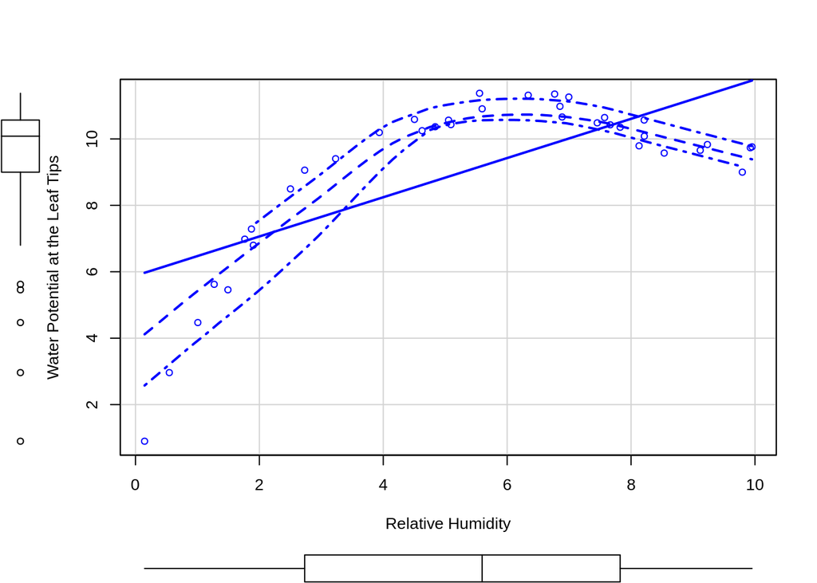

Our scatter plot shows the data looks to be cubic in nature.

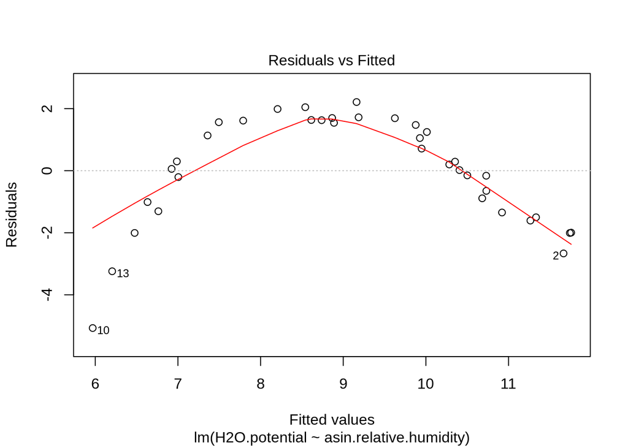

We *might* have a couple of outliers, but they do not appear to affect the outcome.

```
## Analysis of Variance Table
##
## Model 1: H2O.potential ~ asin.relative.humidity
## Model 2: H2O.potential ~ asin.relative.humidity + I(asin.relative.humidity^2)
##   Res.Df     RSS Df Sum of Sq      F    Pr(>F)
## 1     35 107.403
## 2     34  11.479  1    95.924 284.11 < 2.2e-16 ***
## ---
## Signif. codes:  0 '***' 0.001 '**' 0.01 '*' 0.05 '.' 0.1 ' ' 1
```

```
## Analysis of Variance Table
##
## Model 1: H2O.potential ~ asin.relative.humidity + I(asin.relative.humidity^2)
## Model 2: H2O.potential ~ asin.relative.humidity + I(asin.relative.humidity^2) +
##     I(asin.relative.humidity^3)
##   Res.Df     RSS Df Sum of Sq      F  Pr(>F)
## 1     34 11.4794
## 2     33  3.6869  1    7.7925 69.748 1.2e-09 ***
## ---
## Signif. codes:  0 '***' 0.001 '**' 0.01 '*' 0.05 '.' 0.1 ' ' 1
```

Up through this point, all data points to valid variance.

```
## Analysis of Variance Table
##
## Model 1: H2O.potential ~ asin.relative.humidity + I(asin.relative.humidity^2) +
##     I(asin.relative.humidity^3)
## Model 2: H2O.potential ~ asin.relative.humidity + I(asin.relative.humidity^2) +
##     I(asin.relative.humidity^3) + I(asin.relative.humidity^4)
##   Res.Df    RSS Df Sum of Sq     F Pr(>F)
## 1     33 3.6869
## 2     32 3.6104  1  0.076497 0.678 0.4164
```

Here we can see that fitting the data to the 4th degree is not statistically significant (p = 0.4164).

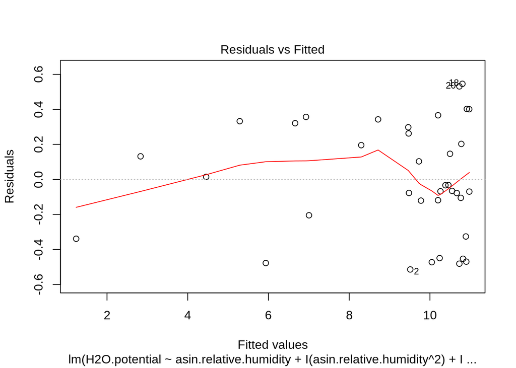

While there may be a possible outlier in the upper ranges of the relative humidity, they do not change the outcome much, if at all.

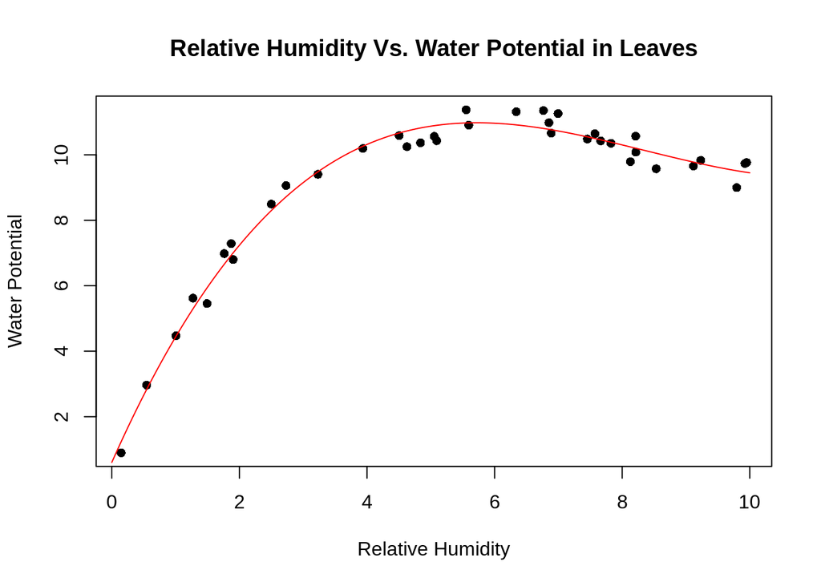

### Conclusion

According to ANOVA, the data is – in fact – cubic (F = 69.748, p <<< 0.05) thus allowing us to reject the null hypothesis.

As the relative humidity increases, the water potential in the leaves increases until the relative humidity reaches a value of ~5.54, at which point the water potential begins to drop off.

## Problem II

> Our botanist, still interested in chiles’ biology, collected seeds from the highest elevation populations and brought them back to the lab. The seeds were weighed, planted, and followed for two weeks to determine which ones GERMINATED (1), and which ones DID NOT GERMINATE (0).

> Our intrepid botanist wanted to predict, based on SEED MASS, which seeds will emerge in two weeks and which ones wouldn’t.

### Justification

All samples were taken from the highest elevation; thus, this is a fixed factor Model I ANOVA.

$H_0:$ No correlation between the seed mass and whether the seeds germinate. This is a fixed effect in that the seeds either germinated or they did not.

### Results

```
##    seed.mass      germination
##  Min.   :14.72   Min.   :0.0000
##  1st Qu.:31.76   1st Qu.:0.0000
##  Median :42.75   Median :1.0000
##  Mean   :50.38   Mean   :0.5667
##  3rd Qu.:68.58   3rd Qu.:1.0000
##  Max.   :96.35   Max.   :1.0000
```

```
##
##  Welch Two Sample t-test
##
## data:  H9P2$seed.mass and H9P2$germination
## t = 11.065, df = 29.024, p-value = 6.261e-12
## alternative hypothesis: true difference in means is not equal to 0
## 95 percent confidence interval:
##  40.60618 59.01984
## sample estimates:
##  mean of x  mean of y
## 50.3796798  0.5666667
```

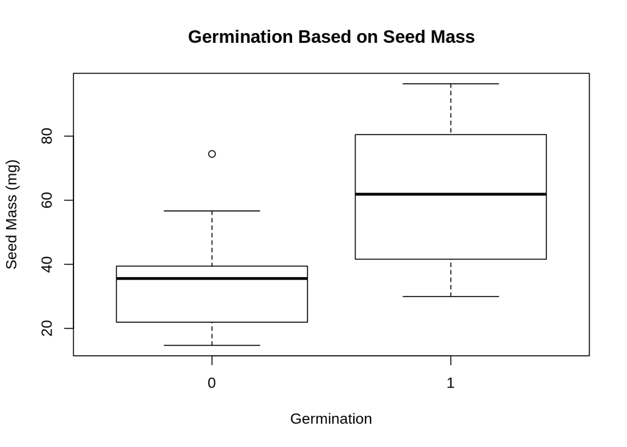

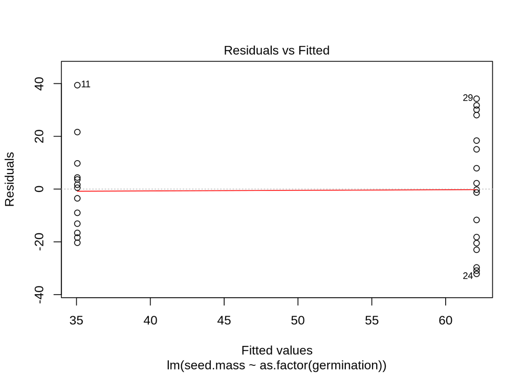

***

Here out residuals are nicely separated nicely.

```
##
## Call:
## glm(formula = H9P2$germination ~ H9P2$seed.mass, family = binomial,
##     data = H9P2)
##
## Deviance Residuals:
##     Min       1Q   Median       3Q      Max
## -2.1025  -0.8566   0.2672   0.7214   1.5445
##
## Coefficients:
##                Estimate Std. Error z value Pr(>|z|)
## (Intercept)    -2.80102    1.19209  -2.350   0.0188 *
## H9P2$seed.mass  0.06575    0.02572   2.557   0.0106 *
## ---
## Signif. codes:  0 '***' 0.001 '**' 0.01 '*' 0.05 '.' 0.1 ' ' 1
##
## (Dispersion parameter for binomial family taken to be 1)
##
##     Null deviance: 41.054  on 29  degrees of freedom
## Residual deviance: 30.210  on 28  degrees of freedom
## AIC: 34.21
##
## Number of Fisher Scoring iterations: 5
```

Here we can see the z-values the coefficients are statistically valid (intercept: p = 0.0188, seed.mass: p = 0.0106)

```
## Analysis of Variance Table
##
## Response: seed.mass
##                        Df  Sum Sq Mean Sq F value   Pr(>F)
## as.factor(germination)  1  5386.2  5386.2  12.324 0.001534 **
## Residuals              28 12237.8   437.1
## ---
## Signif. codes:  0 '***' 0.001 '**' 0.01 '*' 0.05 '.' 0.1 ' ' 1
```

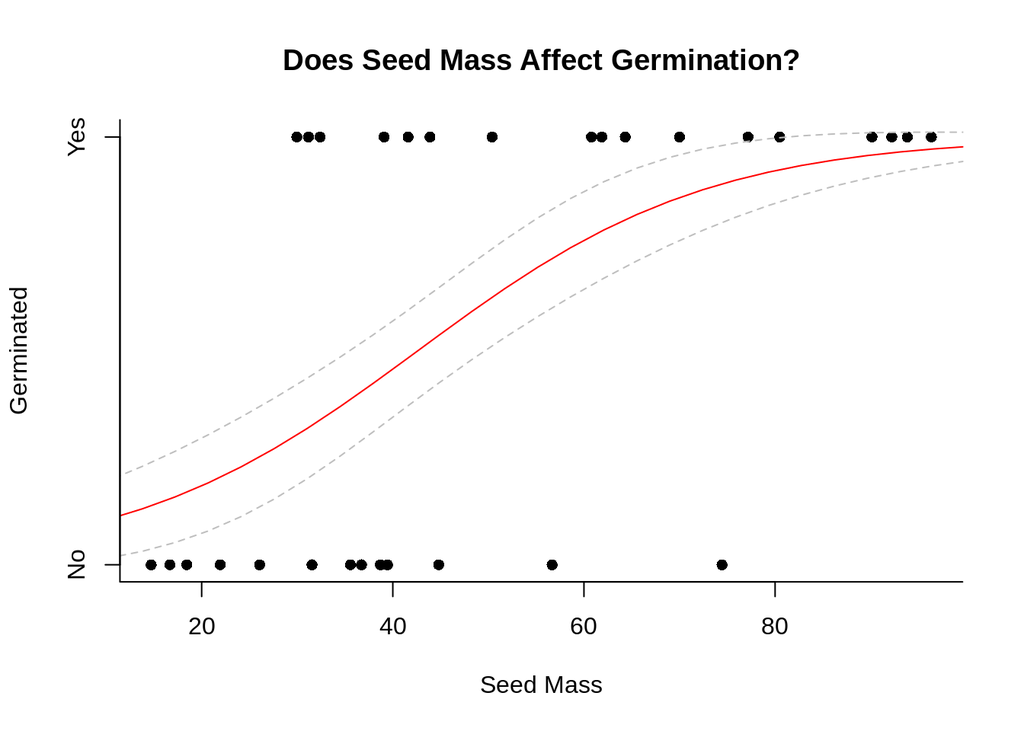

### Conclusion

We are able to reject the null hypothesis as there is obvious variance between seed mass and whether the seeds germinate.